# Data visualization in R First steps with ggplot2

## **Example 1** | Creating a scatter plot

### **1a** | Basic scatter plot

For the first problem we want to represent the **relationship** between the variables `Sepal.Width` and `Sepal.Length` from the `iris` data frame. This data frame a collection of data that quantifies the morphologic variation of **iris flowers** of three related species (setosa, versicolor and virginica).

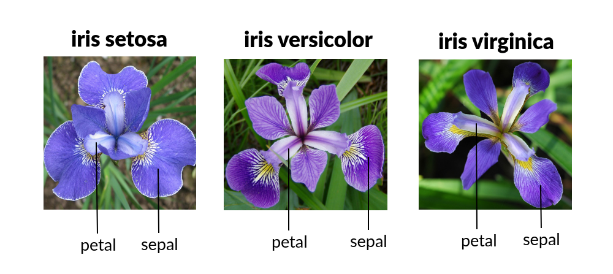

```r
datatable(iris)
```

|  | Sepal.Length | Sepal.Width | Petal.Length | Petal.Width | Species |
| --- | --- | --- | --- | --- | --- |
| 1 | 5.1 | 3.5 | 1.4 | 0.2 | setosa |
| 2 | 4.9 | 3 | 1.4 | 0.2 | setosa |
| 3 | 4.7 | 3.2 | 1.3 | 0.2 | setosa |
| 4 | 4.6 | 3.1 | 1.5 | 0.2 | setosa |
| 5 | 5 | 3.6 | 1.4 | 0.2 | setosa |
| 6 | 5.4 | 3.9 | 1.7 | 0.4 | setosa |
| 7 | 4.6 | 3.4 | 1.4 | 0.3 | setosa |
| 8 | 5 | 3.4 | 1.5 | 0.2 | setosa |
| 9 | 4.4 | 2.9 | 1.4 | 0.2 | setosa |
| 10 | 4.9 | 3.1 | 1.5 | 0.1 | setosa |

[output cut: 140 more lines]

This famous (Fisher’s or Anderson’s) `iris` dataset gives the measurements in centimeters of the variables sepal length and width and petal length and width, respectively, for 50 flowers from each of 3 species of iris. You can type `??iris` in the `R` console to read a description of the data.

To represent any graph in `ggplot2` we need two basic functions that are combined with a `+` sign:

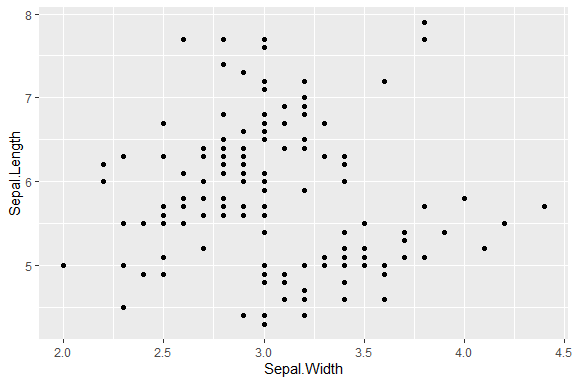

```r
ggplot(data = iris, mapping = aes(x = Sepal.Width, y = Sepal.Length)) +
  geom_point()
```

The variables that we want to represent are wrapped within an `aes()` function, that specifies the *mapping* between the variables and the *aesthetic attributes* (in this case we map them to spatial positions, `x` and `y`). We call the variables directly by their names, because we also pass the entire data frame to the call with the data argument, so `ggplot` knows were to get them from. Finally, we need to add the *geometric object* we want to represent. In this case, points.

### **1b** | Represent extra variables

Another variable in the data indicates the species (`Species`) it was measured. There are three species: setosa, versicolor and virginica.

```r
table(iris$Species)
```

```
##
##     setosa versicolor  virginica
##         50         50         50
```

Let’s say we want to represent the different types of species in different colours. In this case we want to use `Species` as a **categorical variable**, i.e., as a factor. By default, this variable is already a factor:

```r
class(iris$Species)
```

```
## [1] "factor"
```

We use `Species` in the `colour` aesthetic:

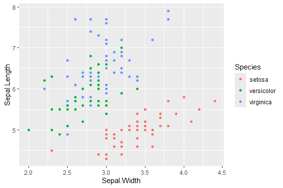

```r
ggplot(data = iris, mapping = aes(x = Sepal.Width, y = Sepal.Length, colour = Species)) +
  geom_point()
```

Note that `ggplot` adds a **legend** by default for all the variables that have been mapped to some aesthetic attribute. This way we can read all the variables without extra effort.

### Exercise

Try mapping `Species` to another aesthetic attribute instead of `colour`, such as `shape`, `size`, `alpha`. Are you getting any warning message? Why?

##### Answer:

## **Example 2** | Creating a bar plot

For this second exercise we are going to use `mtcars` dataset, which contains information about the **fuel consumption and 10 aspects of automobile design and performance for 32 automobiles**.

```r
datatable(mtcars)
```

|  | mpg | cyl | disp | hp | drat | wt | qsec | vs | am | gear | carb |
| --- | --- | --- | --- | --- | --- | --- | --- | --- | --- | --- | --- |
| Mazda RX4 | 21 | 6 | 160 | 110 | 3.9 | 2.62 | 16.46 | 0 | 1 | 4 | 4 |
| Mazda RX4 Wag | 21 | 6 | 160 | 110 | 3.9 | 2.875 | 17.02 | 0 | 1 | 4 | 4 |
| Datsun 710 | 22.8 | 4 | 108 | 93 | 3.85 | 2.32 | 18.61 | 1 | 1 | 4 | 1 |
| Hornet 4 Drive | 21.4 | 6 | 258 | 110 | 3.08 | 3.215 | 19.44 | 1 | 0 | 3 | 1 |
| Hornet Sportabout | 18.7 | 8 | 360 | 175 | 3.15 | 3.44 | 17.02 | 0 | 0 | 3 | 2 |
| Valiant | 18.1 | 6 | 225 | 105 | 2.76 | 3.46 | 20.22 | 1 | 0 | 3 | 1 |
| Duster 360 | 14.3 | 8 | 360 | 245 | 3.21 | 3.57 | 15.84 | 0 | 0 | 3 | 4 |
| Merc 240D | 24.4 | 4 | 146.7 | 62 | 3.69 | 3.19 | 20 | 1 | 0 | 4 | 2 |
| Merc 230 | 22.8 | 4 | 140.8 | 95 | 3.92 | 3.15 | 22.9 | 1 | 0 | 4 | 2 |
| Merc 280 | 19.2 | 6 | 167.6 | 123 | 3.92 | 3.44 | 18.3 | 1 | 0 | 4 | 4 |

[output cut: 22 more lines]

The data was extracted from the 1974 Motor Trend US magazine, and comprises fuel consumption and 10 aspects of automobile design and performance for 32 automobiles (1973–74 models). You can type `??mtcars` in the `R` console to read a description of the data.

One of the variables of interests in the data indicates the number of cylinders of the car engines (`cyl`). There are cars with 4, 6 or 8 cylinders.

### **2a** | Basic bar plot

We want to summarize this data in a simple **bar plot** representing the number of cars in each cylinder category; i.e., how many cars have 4, 6 or 8 cylinders. However, the number of cars with 4 cylinders is not a piece of information present in the dataset, for example. To know the number it is necessary to count the rows where `cyl == 4`, and we are not going to do it .

`ggplot2` is capable to do simple summary operations with the input variables, referred as **statistical tranformations**. One of them is to count the occurrences of each value in a variable, which is precisely what we want to do. And `geom_bar` function happen to use the `count` statistical transformation by default on the variable mapped to the `x` axis.

The first thing that we are going to do is to check the class of the `cyl` variable:

```r
# First we check the class of cyl
class(mtcars$cyl)
```

```
## [1] "numeric"
```

We see that it’s a numeric variable. In this case we want to use `cyl` as a categorical variable, distinguishing groups rather than indicating a value in a numerical continuous scale. For that, we need to change its class before giving it to `ggplot` using the `as.factor()` function.

```r
# We create a new variable in the dataframe, cyl_f, that is cyl converted to factor
mtcars$cyl_f <- as.factor(mtcars$cyl)
```

Now we can create the bar plot:

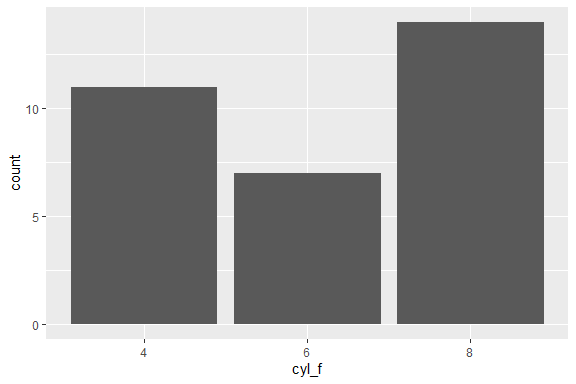

```r
ggplot(data = mtcars, mapping = aes(x = cyl_f)) +
  geom_bar()
```

Imagine that we have already a table with the number of cars with each cylinder category. If we had a pre-computed data frame with `cyl` and `number_of_cars` instead, we could pass `number_of_cars` variable to `geom_col` function instead of `geom_bar`, that by default takes the variables mapped to `x` and `y` without transformation.

```r
# Let's create the data frame
counts_by_cyl_data_frame <- as.data.frame(table(mtcars$cyl))
names(counts_by_cyl_data_frame) <- c("cyl", "number_of_cars")

# See the data frame
counts_by_cyl_data_frame
```

```
##   cyl number_of_cars
## 1   4             11
## 2   6              7
## 3   8             14
```

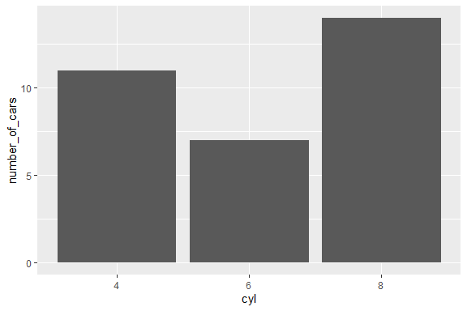

```r
# New graph with geom_col
ggplot(data = counts_by_cyl_data_frame, mapping = aes(x = cyl, y = number_of_cars)) +
  geom_col()
```

We’ll use `geom_bar` if the dataset is not processed and we need to count the occurrences of a category. If we have a processed dataset with the counts, we’ll use `geom_col`.

### **2b** | Groups and position

We have seen in the scatter plot example how to represent groups encoded in extra variables as colours. Say we now want to show transmission type (`am`) in the bar plot, in addition to the number of cylinders. We can map `am` to the filling colour of the bars, `fill` (`colour` aesthetic would change the edges of the rectangles). There are two types of transmission: `0` for automatic cars and `1` for manual cars.

```r
# First we check the class of the variable
class(mtcars$am)
```

```
## [1] "numeric"
```

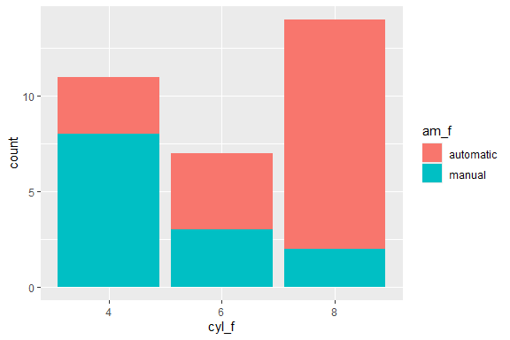

```r
# We make am factor, and we can change the 0/1 notation for a more informative notation: automatic/manual
mtcars$am_f <- factor(mtcars$am, levels = c(0, 1), labels = c("automatic", "manual"))

# Plot
ggplot(data = mtcars, mapping = aes(x = cyl_f, fill = am_f)) +
  geom_bar()
```

Each geometric object in `ggplot2` also has a **position** argument that controls how groups are arranged. In `geom_bar` the default position is to stack the groups. We can change it for a side-by-side position with `position = "dodge"`.

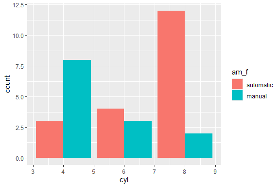

```r
ggplot(data = mtcars, mapping = aes(x = cyl, fill = am_f)) +
  geom_bar(position = "dodge")
```

### Exercise

Update the plot above with the `"fill"` position adjustment instead of `"dodge"`. What it is doing?

##### Answer:

Update the previous plot to group by the variable `gear` instead of the transmission type (`am_f`). `gear` variable is the number of forward gear: cars can have 3, 4 and 5 gears. Check if you need to transform `gear` to a factor.

##### Answer:

## **Example 3** | Showing the distribution of a variable

### **3a** | Simple histogram

Now we have a new dataset called `diamonds` and we need to understand the distribution of some of its continuous variables. A good place to start is a histogram, that represents the number of observations in different ranges as bars.

Note that histograms deal with *continuous* variables while bar plots with *discrete*, but are sometimes [confused](https://www.google.com/search?q=histograms+and+bar+graphs+difference).

```r
datatable(diamonds)
```

|  | carat | cut | color | clarity | depth | table | price | x | y | z |
| --- | --- | --- | --- | --- | --- | --- | --- | --- | --- | --- |
| 1 | 0.23 | Ideal | E | SI2 | 61.5 | 55 | 326 | 3.95 | 3.98 | 2.43 |
| 2 | 0.21 | Premium | E | SI1 | 59.8 | 61 | 326 | 3.89 | 3.84 | 2.31 |
| 3 | 0.23 | Good | E | VS1 | 56.9 | 65 | 327 | 4.05 | 4.07 | 2.31 |
| 4 | 0.29 | Premium | I | VS2 | 62.4 | 58 | 334 | 4.2 | 4.23 | 2.63 |
| 5 | 0.31 | Good | J | SI2 | 63.3 | 58 | 335 | 4.34 | 4.35 | 2.75 |
| 6 | 0.24 | Very Good | J | VVS2 | 62.8 | 57 | 336 | 3.94 | 3.96 | 2.48 |
| 7 | 0.24 | Very Good | I | VVS1 | 62.3 | 57 | 336 | 3.95 | 3.98 | 2.47 |
| 8 | 0.26 | Very Good | H | SI1 | 61.9 | 55 | 337 | 4.07 | 4.11 | 2.53 |
| 9 | 0.22 | Fair | E | VS2 | 65.1 | 61 | 337 | 3.87 | 3.78 | 2.49 |
| 10 | 0.23 | Very Good | H | VS1 | 59.4 | 61 | 338 | 4 | 4.05 | 2.39 |

[output cut: 53930 more lines]

`diamonds` is a dataset containing the prices and other attributes of almost 54,000 diamonds. You can type `??diamonds` in the `R` console to read a description of the data.

The function that we need is called `geom_histogram()` and has the statistical transformation `bin` by default. In this case, `bin` divides the variable mapped to `x` in ranges and counts the number of values in each bin. The number of bins is controlled with the argument `binwidth`. In this example we show the distribution of the weights of diamonds (`carat`).

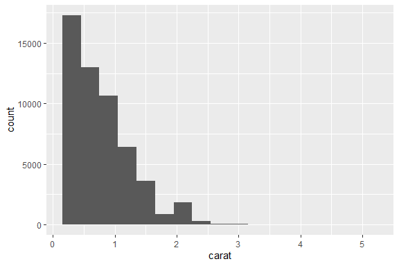

```r
ggplot(data = diamonds, mapping = aes(x = carat)) +
  geom_histogram(binwidth = 0.3)
```

### **3b** | Multiple histograms

The `diamonds` dataset contains more information about diamonds, such as the quality (`cut`) or the color (`color`). To see the distribution of the weight we can try to map it to the filling `cut`:

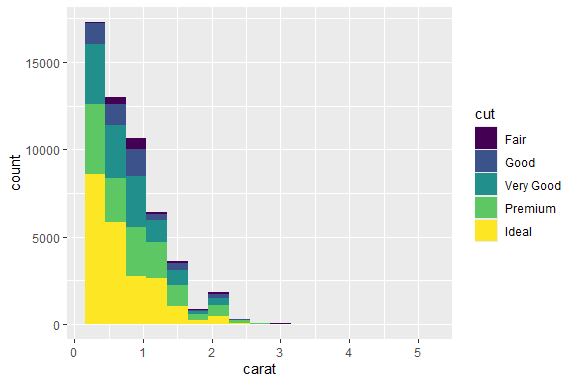

```r
ggplot(data = diamonds, mapping = aes(x = carat, fill = cut)) +
  geom_histogram(binwidth = 0.3)
```

Stacked histograms are difficult to interpret. We can use another position instead of the default “`stacked`” position. For example, using `position = "dodge"`.

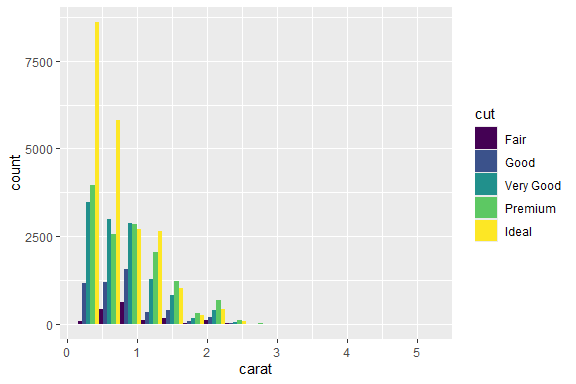

```r
ggplot(data = diamonds, mapping = aes(x = carat, fill = cut)) +
  geom_histogram(position = "dodge", binwidth = 0.3)
```

But there’s even a better option. `ggplot2` provides a simple way of creating small multiples or **facets** with the function `facet_grid`:

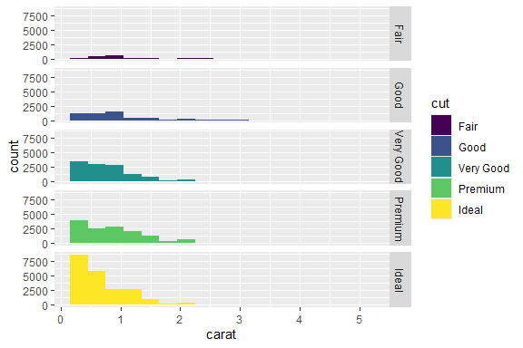

```r
ggplot(data = diamonds, mapping = aes(x = carat, fill = cut)) +
  geom_histogram(position = "dodge", binwidth = 0.3) +
  facet_grid(cut ~ .)
```

### Exercise

What happens if you change the order of the `facet_grid` elements, i.e., `(. ~ cut)`?

##### Answer:

Which is the best subplot configuration to compare the distributions and why?

##### Answer:

## **Example 4** | Customizing a plot

### **4a** | Simple boxplot

Another way of showing the distribution of numerical data is by means of a boxplot. It allows to better understand the skewness through displaying the data quartiles and averages. It also shows outliers as separated dots.

The function that we are going to use is `geom_boxplot()`. In this example we show the distribution of the weights of diamonds (`carat`).

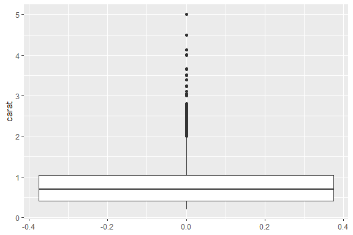

```r
ggplot(data = diamonds, mapping = aes(y = carat)) +
  geom_boxplot()
```

One characteristic of boxplots is that you can show the distribution of one variable (`carat`) with respect to another categorical variable. For example, we can show the distribution of `carat` based on the color of the diamond (`color`).

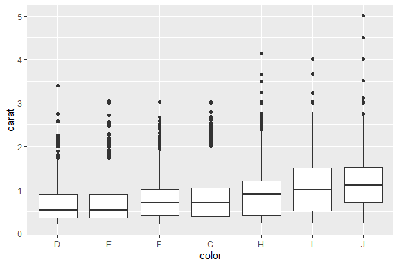

```r
ggplot(data = diamonds, mapping = aes(y = carat, x = color)) +
  geom_boxplot()
```

### Exercise

Try to fill with a color the boxplot. How would you do it?

##### Answer:

## **Example 5** | Customizing a plot

### **5a** | Modify colours

So far we have used the **default colour palettes** for all our representations. We may need to change them to make them accessible to **colour blind people**, match the colour palette of our project or give **meaningful values** (e.g., red for positive and blue for negative). We can control the exact mapping of a variable to an aesthetic attribute with the functions `scale_*`.

In the following example we manually set the color of the five type of diamond qualities. You can use other color names checking the following [R color guide](http://www.stat.columbia.edu/~tzheng/files/Rcolor.pdf).

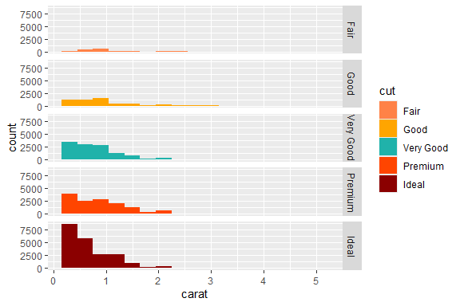

```r
ggplot(data = diamonds, mapping = aes(x = carat, fill = cut)) +
  geom_histogram(position = "dodge", binwidth = 0.3) +
  facet_grid(cut ~ .) +
  scale_fill_manual(values = c("sienna1", "orange", "lightseagreen", "orangered", "red4"))
```

Note that scale functions update both the aesthetic mappings in the plot and in the legend.

### **5b** | Change (or add) axis, legend and plot titles

We may also need to add a **title** to the plot or change the **axis titles**. There are several options for that: * In `ggplot2`, axis and legend titles can be specified with `name` argument within a `scale_*` function * The title can be changed with `+ ggtitle("Title name")` * You can also use the convenience function `labs()`, with `fill = ""` you will set a new legend title and `title = ""` a new title. See the working example:

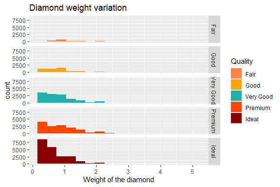

```r
# We save the common part of the plot in a variable and then we can add more components with the "+" sign
p <- ggplot(data = diamonds, mapping = aes(x = carat, fill = cut)) +
  geom_histogram(position = "dodge", binwidth = 0.3) +
  facet_grid(cut ~ .)

# Option A:
p + scale_fill_manual(values = c("sienna1", "orange", "lightseagreen", "orangered", "red4"), name = "Quality") +
  scale_x_continuous(name = "Weight of the diamond") +
  ggtitle("Diamond weight variation")
```

```r
# Option B:
# p + scale_fill_manual(values = c("sienna1", "orange", "lightseagreen", "orangered", "red4")) +
#   labs(title = "Diamond weight variation", x = "Weight of the diamond", fill = "Quality")
```

### **5c** | Change theme

The appearance of `ggplot2` plots is controlled by the **themes**. The default `ggplot2` theme has a gray background and “*is designed to put the data forward yet make comparisons easy*”. You can change the general appearance by choosing a different theme with `theme_*` functions. There are [eight different themes](https://ggplot2.tidyverse.org/reference/ggtheme.html) available. The following example uses the “black and white” theme (`theme_bw()`):

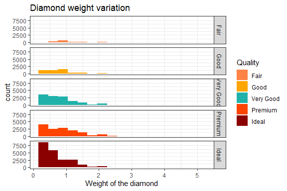

```r
ggplot(data = diamonds, mapping = aes(x = carat, fill = cut)) +
  geom_histogram(position = "dodge", binwidth = 0.3) +
  facet_grid(cut ~ .) +
  scale_fill_manual(values = c("sienna1", "orange", "lightseagreen", "orangered", "red4"), name = "Quality") +
  scale_x_continuous(name = "Weight of the diamond") +
  ggtitle("Diamond weight variation") +
  theme_bw()
```

### Exercise

Using the following code, try other `scale_fill_*` functions in `ggplot2` with pre-defined palettes, such as `scale_fill_hue()`, `scale_fill_brewer()`, `scale_fill_viridis_d()` (default) and `scale_fill_grey()`. Which palette would you use to ensure that colou rblind people can distinguish the colours, `scale_fill_hue()` or `scale_fill_viridis_d()`?

##### Answer:

Try `subtitle = ""`, `caption =""` and `tag =""` arguments from the `labs()` function. What are they for?

##### Answer:

Which theme of the [eight available](https://ggplot2.tidyverse.org/reference/ggtheme.html) do you think that maximizes the data-ink ratio?

##### Answer:

## Saving the plots

There are several ways to save a plot to a file. Here you have a couple of examples:

A. Export button from `RStudio` plot panel:

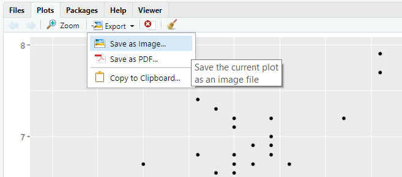

B. `ggsave` function from `ggplot2` package

```r
p <- ggplot(data = iris, mapping = aes(x = Sepal.Width, y = Sepal.Length)) + geom_point()

ggsave(filename = "plot.png", plot = p, width = 6, height = 4) # In inches by default
```

Plots can be saved using different image file formats. Option **A** gives you the format options in a drop list (image format: PNG, JPG, …), option **B** guesses the format from the extension (e.g. `plot.png` or `plot.pdf`).

The main formats can be classified into:

- Raster/bitmat formats, where information is stored in pixels and have a maximum resolution.
  - **PNG**: extension .png, supports transparent background, good compression, doesn’t lose quality
  - **JPEG**: extensions .jpg and .jpeg, very good compression, used in personal photography but suffers from quality degradation with repeated modifications
  - **TIFF**: extensions .tif and .tiff, preferred format for professional printing
- Vector formats, where information is encoded in geometric shapes that can be rendered at any size without losing resolution.
  - **SVG**: extension .svg, standard for vector graphics, requires `svglite` package
- Hybrid
  - **PDF**: can contain both vector graphics and raster images

### Exercise

Save the plot `p` in a raster and a vector format with the same size using `ggsave()` (e.g.: `width = 6, height = 4`). What differences do you observe when you zoom in them?

Note: svg devices require `svglite` R package and other system libraries (`libcairo2-dev` and `libfontconfig1-dev`). Skip the exercise if you get an error!

##### Answer:

## Wrap up exercise

If for representing a scatter plot we use `geom_point()`, a bar plot `geom_bar()` … could you guess how to represent a **line** plot with `ggplot2` syntax?

- Represent how `unemploy` variable changes over time (`date` variable) from `economics` dataset with a line plot using `ggplot2` syntax
- Modify axis names and add a title
- Use a theme
- Save the plot to a file using a raster image format (png)

##### Answer:

The final image should look like this:

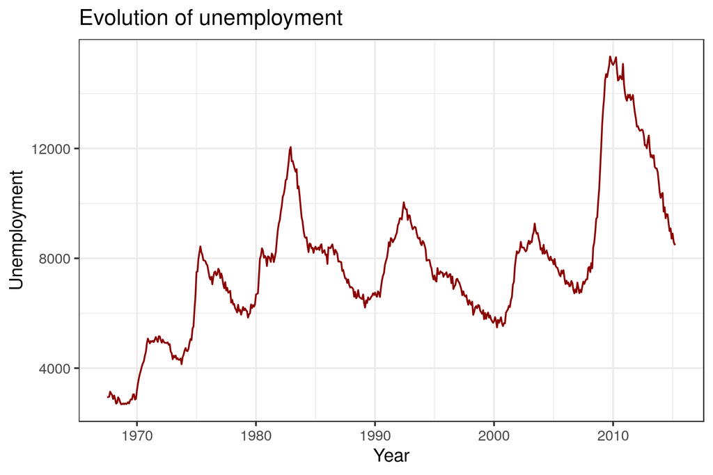

# Try to reproduce a plot!

Pick one (or more!) of the following figures. With your knowledge on `ggplot2` try to write the code that reproduce the same figure.

| Plot | Dataset | Description | Hint |
| --- | --- | --- | --- |
| 1 | `Titanic` | Survival of passengers on the Titanic | Color palette is: “#79AEB2”, “#4A6274” |
| 2 | `ToothGrowth` | The Effect of Vitamin C on Tooth Growth in Guinea Pigs | Color palette is: “#58A6A6”, “#EFA355” |
| 3 | `msleep` | An updated and expanded version of the mammals sleep dataset. | You can color in gray the NA values inside the scale_fill (na.value = “grey80”) |
| 4 | `mpg` | Fuel economy data from 1999 and 2008 for 38 popular models of car | Color palette is: “#4CC3CD”, “#FEE883” |
| 5 | `midwest` | Midwest demographics. | Two aesthetics are combined inside geom_point(), color and size. |
| 6 | `diamonds` | Prices of 50,000 round cut diamonds | The viridis palette is used. |
| 7 | `HairEyeColor` | Hair and Eye Color of Statistics Students | Color palette is: “#58A6A6”, “#EFA355” |
| 8 | `infert` | Infertility after Spontaneous and Induced Abortion | Color palette is: “#900C3F”, “#C70039”, “#FF5733” |

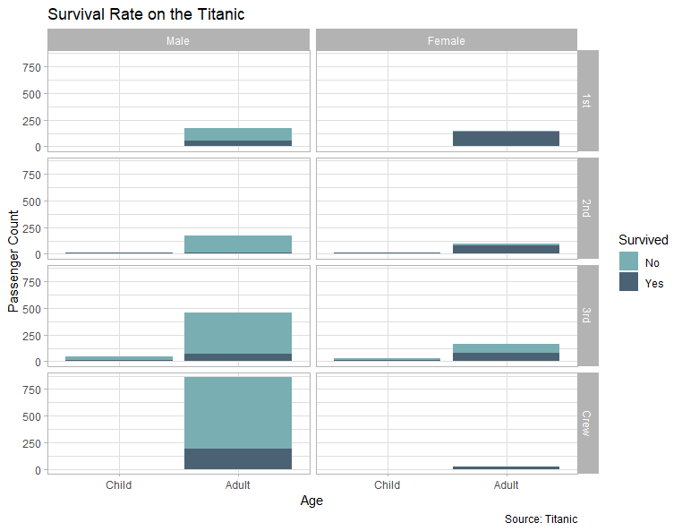

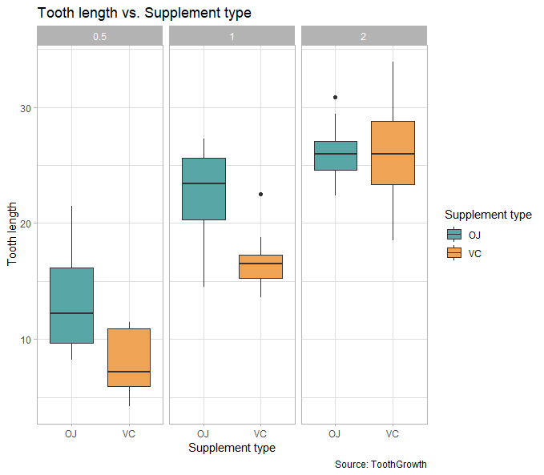

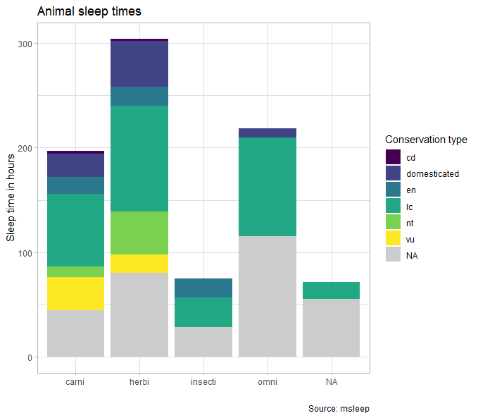

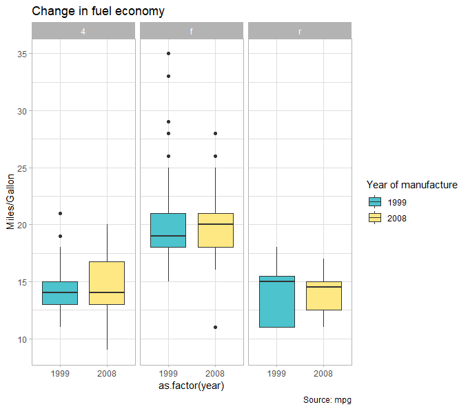

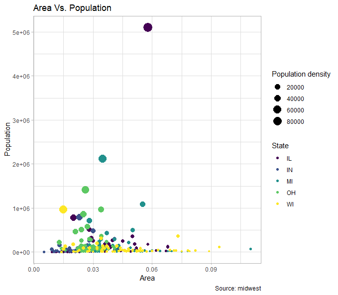

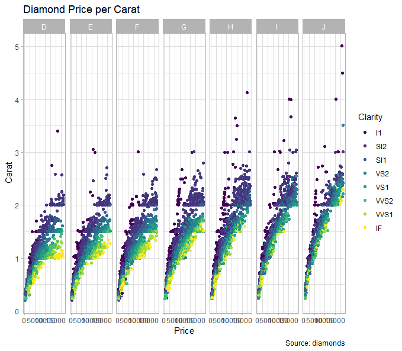

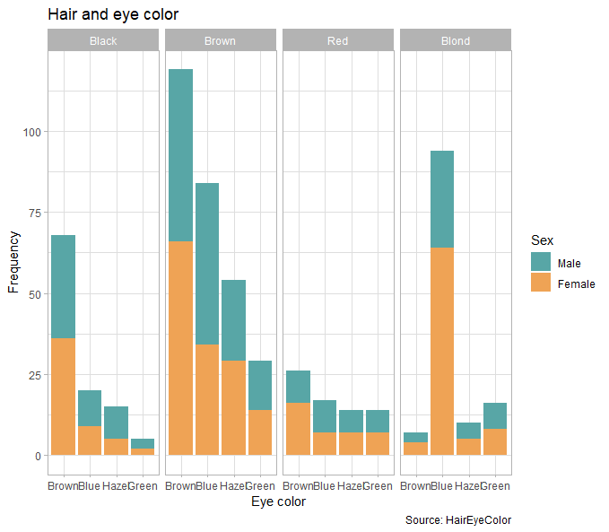

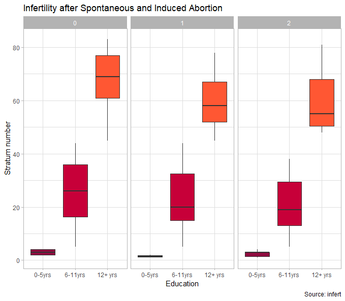